# Factor Analysis

Lizzy Gibson

8/9/2019

## Exploratory Factor Analysis (FA)

Perform an eigenvalue analysis to get an estimate (or range) for the number of underlying dimensions. Recommend fitting at least one more and one less factor than suggested by the eigenvalue analysis.

One way to determine the number of factors or components in a data or correlation matrix is to examine the “scree” plot of the successive eigenvalues. Sharp breaks in the plot suggest the appropriate number of components or factors to extract. “Parallel” analyis is an alternative technique that compares the scree of factors of the observed data with that of a random data matrix of the same size as the original.

***In factor analysis we need to pre-specify the number of factors we want. So is helpful to first run a pca to get an idea of how many factors is a good idea for the factor analysis.

```
##      Comp.1      Comp.2      Comp.3      Comp.4      Comp.5      Comp.6
## 11.39486822  1.93586217  1.05755204  0.71164263  0.59736528  0.45929772
##      Comp.7      Comp.8      Comp.9     Comp.10     Comp.11     Comp.12
##  0.36021834  0.32606188  0.23171343  0.19441661  0.18225066  0.17168942
##     Comp.13     Comp.14     Comp.15     Comp.16     Comp.17     Comp.18
##  0.14649022  0.07267707  0.06737821  0.04429098  0.03118430  0.01504084
```

```
## Importance of components:
##                           Comp.1    Comp.2     Comp.3    Comp.4     Comp.5
## Standard deviation     3.3756286 1.3913526 1.02837349 0.8435891 0.77289409
## Proportion of Variance 0.6330482 0.1075479 0.05875289 0.0395357 0.03318696
## Cumulative Proportion  0.6330482 0.7405961 0.79934902 0.8388847 0.87207169
##                            Comp.6     Comp.7     Comp.8     Comp.9    Comp.10
## Standard deviation     0.67771507 0.60018192 0.57101828 0.48136622 0.44092699
## Proportion of Variance 0.02551654 0.02001213 0.01811455 0.01287297 0.01080092
## Cumulative Proportion  0.89758823 0.91760035 0.93571490 0.94858787 0.95938879
##                           Comp.11     Comp.12     Comp.13     Comp.14
## Standard deviation     0.42690825 0.414354222 0.382740410 0.269586846
## Proportion of Variance 0.01012504 0.009538301 0.008138346 0.004037615
## Cumulative Proportion  0.96951383 0.979052132 0.987190478 0.991228093
##                            Comp.15    Comp.16     Comp.17     Comp.18
## Standard deviation     0.259573128 0.21045423 0.176590770 0.122641089
## Proportion of Variance 0.003743234 0.00246061 0.001732461 0.000835602
## Cumulative Proportion  0.994971327 0.99743194 0.999164398 1.000000000
```

### Orthogonal Models

Orthogonal rotation is used if it is desirable to identify factors that are as independent from one another as possible. In Factor analysis you get values for uniqueness and comparativeness.

```
## Factor Analysis using method =  ml
## Call: fa(r = logstudypop, nfactors = 2, n.obs = 1003, rotate = "varimax",
##     scores = "regression", fm = "ml")
## Standardized loadings (pattern matrix) based upon correlation matrix
##          item  ML1  ML2    h2    u2 com
## lbx170la    6 0.91 0.38 0.971 0.029 1.3
## lbx180la    7 0.91 0.35 0.947 0.053 1.3
## lbx194la   18 0.89 0.25 0.853 0.147 1.2
## lbx187la    8 0.83 0.43 0.872 0.128 1.5
## lbx153la    5 0.81 0.54 0.946 0.054 1.7
## lbxhxcla   17 0.77 0.37 0.732 0.268 1.4
## lbx138la    4 0.74 0.62 0.922 0.078 1.9
## lbxd03la    9 0.56 0.46 0.521 0.479 1.9
## lbxf03la   12 0.49 0.48 0.470 0.530 2.0
## lbx118la    3 0.46 0.83 0.902 0.098 1.6
## lbx099la    2 0.49 0.75 0.813 0.187 1.7
## lbx074la    1 0.54 0.72 0.808 0.192 1.8
## lbxpcbla   16 0.22 0.66 0.483 0.517 1.2
## lbxd05la   10 0.13 0.56 0.328 0.672 1.1
## lbxf04la   13 0.42 0.54 0.468 0.532 1.9
## lbxd07la   11 0.27 0.54 0.360 0.640 1.5
## lbxf05la   14 0.42 0.50 0.431 0.569 1.9
## lbxf08la   15 0.14 0.25 0.084 0.916 1.6
##
##                        ML1  ML2
## SS loadings           6.73 5.18
## Proportion Var        0.37 0.29
## Cumulative Var        0.37 0.66
## Proportion Explained  0.56 0.44
## Cumulative Proportion 0.56 1.00
##
## Mean item complexity =  1.6
## Test of the hypothesis that 2 factors are sufficient.
##
## df null model =  153  with the objective function =  25.21 with Chi Square =  25089.85
## df of  the model are 118  and the objective function was  4.97
##
## The root mean square of the residuals (RMSR) is  0.09
## The df corrected root mean square of the residuals is  0.1
##
## The harmonic n.obs is  1003 with the empirical chi square  1304.52  with prob <  0.000000000000000000000000000000000000000000000000000000000000…
## The total n.obs was  1003  with Likelihood Chi Square =  4938.07  with prob <  0
##
## Tucker Lewis Index of factoring reliability =  0.749
## RMSEA index =  0.202  and the 90 % confidence intervals are  0.197 0.207
## BIC =  4122.6
## Fit based upon off diagonal values = 0.98
## Measures of factor score adequacy
##                                                    ML1  ML2
## Correlation of (regression) scores with factors   0.98 0.95
## Multiple R square of scores with factors          0.96 0.90
## Minimum correlation of possible factor scores     0.91 0.81
```

```
## Factor Analysis using method =  ml
## Call: fa(r = logstudypop, nfactors = 3, n.obs = 1003, rotate = "varimax",
##     scores = "regression", fm = "ml")
## Standardized loadings (pattern matrix) based upon correlation matrix
##          item  ML1  ML3  ML2   h2    u2 com
## lbx180la    7 0.90 0.24 0.28 0.95 0.049 1.3
## lbx170la    6 0.90 0.24 0.32 0.96 0.035 1.4
## lbx194la   18 0.87 0.22 0.18 0.84 0.158 1.2
## lbx187la    8 0.82 0.25 0.36 0.87 0.134 1.6
## lbx153la    5 0.81 0.25 0.48 0.95 0.045 1.8
## lbxhxcla   17 0.75 0.37 0.23 0.76 0.235 1.7
## lbx138la    4 0.74 0.25 0.56 0.93 0.066 2.1
## lbxf04la   13 0.36 0.77 0.25 0.79 0.213 1.6
## lbxf05la   14 0.37 0.73 0.22 0.72 0.284 1.7
## lbxd05la   10 0.08 0.66 0.32 0.54 0.456 1.5
## lbxd07la   11 0.21 0.65 0.30 0.55 0.446 1.7
## lbxf08la   15 0.08 0.61 0.00 0.38 0.619 1.0
## lbxd03la    9 0.52 0.59 0.23 0.67 0.327 2.3
## lbxf03la   12 0.46 0.51 0.29 0.55 0.446 2.6
## lbx118la    3 0.46 0.31 0.78 0.92 0.083 2.0
## lbx099la    2 0.50 0.23 0.73 0.84 0.159 2.0
## lbx074la    1 0.53 0.29 0.67 0.81 0.185 2.3
## lbxpcbla   16 0.21 0.40 0.54 0.49 0.508 2.2
##
##                        ML1  ML3  ML2
## SS loadings           6.43 3.85 3.28
## Proportion Var        0.36 0.21 0.18
## Cumulative Var        0.36 0.57 0.75
## Proportion Explained  0.47 0.28 0.24
## Cumulative Proportion 0.47 0.76 1.00
##
## Mean item complexity =  1.8
## Test of the hypothesis that 3 factors are sufficient.
##
## df null model =  153  with the objective function =  25.21 with Chi Square =  25089.85
## df of  the model are 102  and the objective function was  2.97
##
## The root mean square of the residuals (RMSR) is  0.03
## The df corrected root mean square of the residuals is  0.04
##
## The harmonic n.obs is  1003 with the empirical chi square  172.28  with prob <  0.000017
## The total n.obs was  1003  with Likelihood Chi Square =  2954.31  with prob <  0
##
## Tucker Lewis Index of factoring reliability =  0.828
## RMSEA index =  0.167  and the 90 % confidence intervals are  0.162 0.172
## BIC =  2249.41
## Fit based upon off diagonal values = 1
## Measures of factor score adequacy
##                                                    ML1  ML3  ML2
## Correlation of (regression) scores with factors   0.98 0.93 0.94
## Multiple R square of scores with factors          0.96 0.86 0.89
## Minimum correlation of possible factor scores     0.92 0.72 0.78
```

```
## Factor Analysis using method =  ml
## Call: fa(r = logstudypop, nfactors = 4, n.obs = 1003, rotate = "varimax",
##     scores = "regression", fm = "ml")
## Standardized loadings (pattern matrix) based upon correlation matrix
##          item  ML1  ML4  ML2   ML3   h2    u2 com
## lbx170la    6 0.90 0.25 0.32 -0.01 0.97 0.030 1.4
## lbx194la   18 0.90 0.21 0.20 -0.23 0.94 0.062 1.4
## lbx180la    7 0.89 0.25 0.27  0.10 0.95 0.054 1.4
## lbx187la    8 0.83 0.25 0.37 -0.08 0.90 0.101 1.6
## lbx153la    5 0.81 0.26 0.45  0.26 1.00 0.005 2.0
## lbxhxcla   17 0.75 0.39 0.22  0.10 0.77 0.234 1.7
## lbx138la    4 0.74 0.26 0.53  0.26 0.97 0.033 2.4
## lbxf04la   13 0.35 0.77 0.26  0.03 0.79 0.215 1.6
## lbxf05la   14 0.36 0.73 0.23  0.03 0.71 0.287 1.7
## lbxd05la   10 0.07 0.65 0.34 -0.06 0.55 0.448 1.6
## lbxd07la   11 0.21 0.64 0.31 -0.01 0.56 0.444 1.7
## lbxf08la   15 0.08 0.61 0.00  0.02 0.38 0.616 1.0
## lbxd03la    9 0.51 0.61 0.21  0.15 0.70 0.305 2.3
## lbxf03la   12 0.46 0.51 0.30  0.00 0.55 0.446 2.6
## lbx118la    3 0.45 0.29 0.81  0.02 0.95 0.054 1.9
## lbx099la    2 0.51 0.23 0.72  0.08 0.83 0.170 2.1
## lbx074la    1 0.54 0.28 0.69 -0.06 0.84 0.156 2.3
## lbxpcbla   16 0.20 0.40 0.57 -0.01 0.51 0.486 2.1
##
##                        ML1  ML4  ML2  ML3
## SS loadings           6.44 3.85 3.32 0.25
## Proportion Var        0.36 0.21 0.18 0.01
## Cumulative Var        0.36 0.57 0.76 0.77
## Proportion Explained  0.46 0.28 0.24 0.02
## Cumulative Proportion 0.46 0.74 0.98 1.00
##
## Mean item complexity =  1.8
## Test of the hypothesis that 4 factors are sufficient.
##
## df null model =  153  with the objective function =  25.21 with Chi Square =  25089.85
## df of  the model are 87  and the objective function was  1.48
##
## The root mean square of the residuals (RMSR) is  0.03
## The df corrected root mean square of the residuals is  0.04
##
## The harmonic n.obs is  1003 with the empirical chi square  150.15  with prob <  0.000031
## The total n.obs was  1003  with Likelihood Chi Square =  1465.8  with prob <  0.000000000000000000000000000000000000000000000000000000000000…
##
## Tucker Lewis Index of factoring reliability =  0.903
## RMSEA index =  0.126  and the 90 % confidence intervals are  0.12 0.131
## BIC =  864.57
## Fit based upon off diagonal values = 1
## Measures of factor score adequacy
##                                                    ML1  ML4  ML2  ML3
## Correlation of (regression) scores with factors   0.98 0.93 0.95 0.93
## Multiple R square of scores with factors          0.97 0.86 0.91 0.87
## Minimum correlation of possible factor scores     0.94 0.73 0.82 0.73
```

```
## Factor Analysis using method =  ml
## Call: fa(r = logstudypop, nfactors = 5, n.obs = 1003, rotate = "varimax",
##     scores = "regression", fm = "ml")
## Standardized loadings (pattern matrix) based upon correlation matrix
##          item  ML1  ML5  ML3  ML2   ML4   h2    u2 com
## lbx170la    6 0.90 0.31 0.22 0.14 -0.01 0.97 0.030 1.4
## lbx194la   18 0.89 0.19 0.20 0.12 -0.22 0.94 0.063 1.4
## lbx180la    7 0.89 0.26 0.24 0.12  0.10 0.94 0.055 1.4
## lbx187la    8 0.83 0.36 0.21 0.16 -0.08 0.90 0.102 1.6
## lbx153la    5 0.81 0.44 0.23 0.14  0.26 1.00 0.005 2.1
## lbx138la    4 0.74 0.52 0.21 0.17  0.27 0.97 0.033 2.4
## lbxhxcla   17 0.73 0.24 0.40 0.10  0.08 0.77 0.227 1.9
## lbxd03la    9 0.51 0.20 0.49 0.36  0.15 0.69 0.306 3.3
## lbx118la    3 0.46 0.81 0.19 0.23  0.02 0.96 0.045 1.9
## lbx099la    2 0.52 0.70 0.16 0.18  0.09 0.82 0.177 2.2
## lbx074la    1 0.54 0.68 0.19 0.21 -0.05 0.84 0.159 2.3
## lbxpcbla   16 0.19 0.59 0.31 0.22 -0.02 0.52 0.477 2.1
## lbxf05la   14 0.32 0.28 0.76 0.19  0.00 0.79 0.206 1.8
## lbxf04la   13 0.32 0.30 0.72 0.29  0.01 0.79 0.205 2.2
## lbxf08la   15 0.06 0.01 0.54 0.29  0.01 0.38 0.622 1.6
## lbxf03la   12 0.44 0.34 0.53 0.10 -0.02 0.60 0.397 2.8
## lbxd07la   11 0.22 0.22 0.33 0.81  0.04 0.86 0.141 1.7
## lbxd05la   10 0.08 0.28 0.36 0.72 -0.03 0.74 0.264 1.8
##
##                        ML1  ML5  ML3  ML2  ML4
## SS loadings           6.37 3.25 2.79 1.83 0.25
## Proportion Var        0.35 0.18 0.15 0.10 0.01
## Cumulative Var        0.35 0.53 0.69 0.79 0.80
## Proportion Explained  0.44 0.22 0.19 0.13 0.02
## Cumulative Proportion 0.44 0.66 0.86 0.98 1.00
##
## Mean item complexity =  2
## Test of the hypothesis that 5 factors are sufficient.
##
## df null model =  153  with the objective function =  25.21 with Chi Square =  25089.85
## df of  the model are 73  and the objective function was  0.91
##
## The root mean square of the residuals (RMSR) is  0.02
## The df corrected root mean square of the residuals is  0.03
##
## The harmonic n.obs is  1003 with the empirical chi square  49.37  with prob <  0.98
## The total n.obs was  1003  with Likelihood Chi Square =  906.87  with prob <  0.0000000000000000000000000000000000000000000000000000000000000000000000000000000000000000000000000000000000000000000000000000000000000000000000042
##
## Tucker Lewis Index of factoring reliability =  0.93
## RMSEA index =  0.107  and the 90 % confidence intervals are  0.101 0.113
## BIC =  402.39
## Fit based upon off diagonal values = 1
## Measures of factor score adequacy
##                                                    ML1  ML5  ML3  ML2  ML4
## Correlation of (regression) scores with factors   0.98 0.96 0.90 0.90 0.93
## Multiple R square of scores with factors          0.97 0.91 0.82 0.82 0.87
## Minimum correlation of possible factor scores     0.94 0.83 0.63 0.63 0.73
```

### Oblique Models

Oblique rotation (i.e. correlated factors) are commonly used since we often hypothesize our latent variables of interest to be correlated with one another. Rotated ortogonal solution to get correlated results. In the orthogonal solution we only get uncorrelated results.

```
## Factor Analysis using method =  ml
## Call: fa(r = logstudypop, nfactors = 2, n.obs = 1003, rotate = "promax",
##     scores = "regression", fm = "ml")
## Standardized loadings (pattern matrix) based upon correlation matrix
##          item   ML1   ML2    h2    u2 com
## lbx194la   18  1.08 -0.23 0.853 0.147 1.1
## lbx180la    7  1.04 -0.09 0.947 0.053 1.0
## lbx170la    6  1.02 -0.04 0.971 0.029 1.0
## lbx187la    8  0.88  0.07 0.872 0.128 1.0
## lbxhxcla   17  0.83  0.03 0.732 0.268 1.0
## lbx153la    5  0.78  0.24 0.946 0.054 1.2
## lbx138la    4  0.63  0.39 0.922 0.078 1.7
## lbxd03la    9  0.48  0.28 0.521 0.479 1.6
## lbxf03la   12  0.38  0.35 0.470 0.530 2.0
## lbx118la    3  0.10  0.87 0.902 0.098 1.0
## lbxpcbla   16 -0.12  0.78 0.483 0.517 1.0
## lbx099la    2  0.20  0.74 0.813 0.187 1.1
## lbxd05la   10 -0.17  0.69 0.328 0.672 1.1
## lbx074la    1  0.28  0.67 0.808 0.192 1.3
## lbxd07la   11  0.02  0.58 0.360 0.640 1.0
## lbxf04la   13  0.23  0.49 0.468 0.532 1.4
## lbxf05la   14  0.27  0.43 0.431 0.569 1.7
## lbxf08la   15  0.03  0.26 0.084 0.916 1.0
##
##                        ML1  ML2
## SS loadings           7.10 4.81
## Proportion Var        0.39 0.27
## Cumulative Var        0.39 0.66
## Proportion Explained  0.60 0.40
## Cumulative Proportion 0.60 1.00
##
##  With factor correlations of
##      ML1  ML2
## ML1 1.00 0.76
## ML2 0.76 1.00
##
## Mean item complexity =  1.2
## Test of the hypothesis that 2 factors are sufficient.
##
## df null model =  153  with the objective function =  25.21 with Chi Square =  25089.85
## df of  the model are 118  and the objective function was  4.97
##
## The root mean square of the residuals (RMSR) is  0.09
## The df corrected root mean square of the residuals is  0.1
##
## The harmonic n.obs is  1003 with the empirical chi square  1304.52  with prob <  0.000000000000000000000000000000000000000000000000000000000000…
## The total n.obs was  1003  with Likelihood Chi Square =  4938.07  with prob <  0
##
## Tucker Lewis Index of factoring reliability =  0.749
## RMSEA index =  0.202  and the 90 % confidence intervals are  0.197 0.207
## BIC =  4122.6
## Fit based upon off diagonal values = 0.98
## Measures of factor score adequacy
##                                                   ML1 ML2
## Correlation of (regression) scores with factors     1   1
## Multiple R square of scores with factors            1   1
## Minimum correlation of possible factor scores       1   1
```

```
## Factor Analysis using method =  ml
## Call: fa(r = logstudypop, nfactors = 3, n.obs = 1003, rotate = "promax",
##     scores = "regression", fm = "ml")
## Standardized loadings (pattern matrix) based upon correlation matrix
##          item   ML1   ML2   ML3   h2    u2 com
## lbx194la   18  1.02 -0.13 -0.03 0.84 0.158 1.0
## lbx180la    7  1.00 -0.01 -0.04 0.95 0.049 1.0
## lbx170la    6  0.97  0.06 -0.05 0.96 0.035 1.0
## lbx187la    8  0.84  0.15 -0.03 0.87 0.134 1.1
## lbxhxcla   17  0.79 -0.05  0.18 0.76 0.235 1.1
## lbx153la    5  0.77  0.33 -0.08 0.95 0.045 1.4
## lbx138la    4  0.63  0.47 -0.09 0.93 0.066 1.9
## lbx118la    3  0.10  0.89 -0.02 0.92 0.083 1.0
## lbx099la    2  0.21  0.82 -0.10 0.84 0.159 1.2
## lbx074la    1  0.27  0.70 -0.02 0.81 0.185 1.3
## lbxpcbla   16 -0.12  0.60  0.26 0.49 0.508 1.4
## lbxf04la   13  0.14  0.03  0.78 0.79 0.213 1.1
## lbxf08la   15 -0.04 -0.20  0.74 0.38 0.619 1.1
## lbxf05la   14  0.18 -0.01  0.73 0.72 0.284 1.1
## lbxd05la   10 -0.24  0.27  0.69 0.54 0.456 1.6
## lbxd07la   11 -0.04  0.19  0.64 0.55 0.446 1.2
## lbxd03la    9  0.43 -0.03  0.52 0.67 0.327 1.9
## lbxf03la   12  0.33  0.11  0.41 0.55 0.446 2.1
##
##                        ML1  ML2  ML3
## SS loadings           6.60 3.60 3.35
## Proportion Var        0.37 0.20 0.19
## Cumulative Var        0.37 0.57 0.75
## Proportion Explained  0.49 0.27 0.25
## Cumulative Proportion 0.49 0.75 1.00
##
##  With factor correlations of
##      ML1  ML2  ML3
## ML1 1.00 0.72 0.58
## ML2 0.72 1.00 0.63
## ML3 0.58 0.63 1.00
##
## Mean item complexity =  1.3
## Test of the hypothesis that 3 factors are sufficient.
##
## df null model =  153  with the objective function =  25.21 with Chi Square =  25089.85
## df of  the model are 102  and the objective function was  2.97
##
## The root mean square of the residuals (RMSR) is  0.03
## The df corrected root mean square of the residuals is  0.04
##
## The harmonic n.obs is  1003 with the empirical chi square  172.28  with prob <  0.000017
## The total n.obs was  1003  with Likelihood Chi Square =  2954.31  with prob <  0
##
## Tucker Lewis Index of factoring reliability =  0.828
## RMSEA index =  0.167  and the 90 % confidence intervals are  0.162 0.172
## BIC =  2249.41
## Fit based upon off diagonal values = 1
## Measures of factor score adequacy
##                                                    ML1  ML2  ML3
## Correlation of (regression) scores with factors   0.99 0.99 0.86
## Multiple R square of scores with factors          0.97 0.97 0.74
## Minimum correlation of possible factor scores     0.95 0.95 0.49
```

```
## Factor Analysis using method =  ml
## Call: fa(r = logstudypop, nfactors = 4, rotate = "promax", scores = "regression",
##     fm = "ml")
## Standardized loadings (pattern matrix) based upon correlation matrix
##          item   ML1   ML2   ML4   ML3   h2    u2 com
## lbx194la   18  1.18 -0.06 -0.02 -0.30 0.94 0.062 1.1
## lbx170la    6  0.98  0.06 -0.04 -0.02 0.97 0.030 1.0
## lbx180la    7  0.93 -0.03 -0.02  0.11 0.95 0.054 1.0
## lbx187la    8  0.91  0.17 -0.03 -0.11 0.90 0.101 1.1
## lbxhxcla   17  0.73 -0.07  0.20  0.11 0.77 0.234 1.2
## lbx153la    5  0.63  0.22 -0.07  0.33 1.00 0.005 1.8
## lbx138la    4  0.49  0.36 -0.08  0.35 0.97 0.033 2.8
## lbx118la    3  0.12  0.88 -0.04  0.07 0.95 0.054 1.1
## lbx099la    2  0.22  0.74 -0.11  0.14 0.83 0.170 1.3
## lbx074la    1  0.34  0.70 -0.03 -0.04 0.84 0.156 1.5
## lbxpcbla   16 -0.11  0.61  0.24  0.02 0.51 0.486 1.4
## lbxf04la   13  0.12  0.03  0.78  0.02 0.79 0.215 1.1
## lbxf08la   15 -0.05 -0.19  0.74 -0.01 0.38 0.616 1.1
## lbxf05la   14  0.16  0.00  0.73  0.02 0.71 0.287 1.1
## lbxd05la   10 -0.19  0.30  0.67 -0.08 0.55 0.448 1.6
## lbxd07la   11 -0.02  0.20  0.64 -0.02 0.56 0.444 1.2
## lbxd03la    9  0.34 -0.07  0.53  0.17 0.70 0.305 2.0
## lbxf03la   12  0.33  0.12  0.40  0.00 0.55 0.446 2.1
##
##                        ML1  ML2  ML4  ML3
## SS loadings           6.48 3.35 3.34 0.69
## Proportion Var        0.36 0.19 0.19 0.04
## Cumulative Var        0.36 0.55 0.73 0.77
## Proportion Explained  0.47 0.24 0.24 0.05
## Cumulative Proportion 0.47 0.71 0.95 1.00
##
##  With factor correlations of
##      ML1  ML2  ML4  ML3
## ML1 1.00 0.68 0.58 0.62
## ML2 0.68 1.00 0.61 0.46
## ML4 0.58 0.61 1.00 0.44
## ML3 0.62 0.46 0.44 1.00
##
## Mean item complexity =  1.4
## Test of the hypothesis that 4 factors are sufficient.
##
## df null model =  153  with the objective function =  25.21 with Chi Square =  25089.85
## df of  the model are 87  and the objective function was  1.48
##
## The root mean square of the residuals (RMSR) is  0.03
## The df corrected root mean square of the residuals is  0.04
##
## The harmonic n.obs is  1003 with the empirical chi square  150.15  with prob <  0.000031
## The total n.obs was  1003  with Likelihood Chi Square =  1465.8  with prob <  0.000000000000000000000000000000000000000000000000000000000000…
##
## Tucker Lewis Index of factoring reliability =  0.903
## RMSEA index =  0.126  and the 90 % confidence intervals are  0.12 0.131
## BIC =  864.57
## Fit based upon off diagonal values = 1
## Measures of factor score adequacy
##                                                    ML1  ML2  ML4  ML3
## Correlation of (regression) scores with factors   0.96 0.79 0.84 0.82
## Multiple R square of scores with factors          0.92 0.62 0.70 0.67
## Minimum correlation of possible factor scores     0.84 0.25 0.41 0.35
```

```
## Factor Analysis using method =  ml
## Call: fa(r = logstudypop, nfactors = 5, n.obs = 1003, rotate = "promax",
##     scores = "regression", fm = "ml")
## Standardized loadings (pattern matrix) based upon correlation matrix
##          item   ML1   ML2   ML5   ML3   ML4   h2    u2 com
## lbx194la   18  1.17 -0.08 -0.03  0.04 -0.30 0.94 0.063 1.1
## lbx170la    6  0.99  0.02 -0.04  0.02 -0.01 0.97 0.030 1.0
## lbx180la    7  0.94 -0.07  0.00 -0.02  0.13 0.94 0.055 1.0
## lbx187la    8  0.91  0.14 -0.05  0.05 -0.10 0.90 0.102 1.1
## lbxhxcla   17  0.69 -0.05  0.28 -0.09  0.10 0.77 0.227 1.4
## lbx153la    5  0.65  0.17 -0.04 -0.04  0.35 1.00 0.005 1.7
## lbx138la    4  0.51  0.30 -0.08  0.00  0.37 0.97 0.033 2.6
## lbx118la    3  0.10  0.89 -0.08  0.05  0.06 0.96 0.045 1.1
## lbx099la    2  0.21  0.71 -0.11  0.01  0.15 0.82 0.177 1.3
## lbx074la    1  0.33  0.69 -0.07  0.06 -0.04 0.84 0.159 1.5
## lbxpcbla   16 -0.16  0.67  0.20  0.05  0.00 0.52 0.477 1.3
## lbxf05la   14  0.04  0.12  0.86 -0.10 -0.02 0.79 0.206 1.1
## lbxf04la   13  0.05  0.12  0.76  0.05  0.00 0.79 0.205 1.1
## lbxf08la   15 -0.08 -0.15  0.62  0.16 -0.01 0.38 0.622 1.3
## lbxf03la   12  0.24  0.22  0.55 -0.14 -0.03 0.60 0.397 1.9
## lbxd03la    9  0.36 -0.10  0.36  0.21  0.18 0.69 0.306 3.3
## lbxd07la   11  0.11  0.00  0.03  0.85  0.03 0.86 0.141 1.0
## lbxd05la   10 -0.10  0.18  0.13  0.73 -0.05 0.74 0.264 1.2
##
##                        ML1  ML2  ML5  ML3  ML4
## SS loadings           6.38 3.23 2.55 1.57 0.75
## Proportion Var        0.35 0.18 0.14 0.09 0.04
## Cumulative Var        0.35 0.53 0.68 0.76 0.80
## Proportion Explained  0.44 0.22 0.18 0.11 0.05
## Cumulative Proportion 0.44 0.66 0.84 0.95 1.00
##
##  With factor correlations of
##      ML1  ML2  ML5  ML3  ML4
## ML1 1.00 0.71 0.60 0.37 0.62
## ML2 0.71 1.00 0.58 0.48 0.55
## ML5 0.60 0.58 1.00 0.64 0.50
## ML3 0.37 0.48 0.64 1.00 0.38
## ML4 0.62 0.55 0.50 0.38 1.00
##
## Mean item complexity =  1.4
## Test of the hypothesis that 5 factors are sufficient.
##
## df null model =  153  with the objective function =  25.21 with Chi Square =  25089.85
## df of  the model are 73  and the objective function was  0.91
##
## The root mean square of the residuals (RMSR) is  0.02
## The df corrected root mean square of the residuals is  0.03
##
## The harmonic n.obs is  1003 with the empirical chi square  49.37  with prob <  0.98
## The total n.obs was  1003  with Likelihood Chi Square =  906.87  with prob <  0.0000000000000000000000000000000000000000000000000000000000000000000000000000000000000000000000000000000000000000000000000000000000000000000000042
##
## Tucker Lewis Index of factoring reliability =  0.93
## RMSEA index =  0.107  and the 90 % confidence intervals are  0.101 0.113
## BIC =  402.39
## Fit based upon off diagonal values = 1
## Measures of factor score adequacy
##                                                    ML1  ML2  ML5  ML3  ML4
## Correlation of (regression) scores with factors   0.95 0.77 0.76 0.80 0.85
## Multiple R square of scores with factors          0.90 0.59 0.58 0.63 0.72
## Minimum correlation of possible factor scores     0.80 0.18 0.16 0.27 0.43
```

### Fit Indices

BIC – lower (better fit)

eBIC – When normal theory fails (e.g., in the case of non-positive definite matrices), it useful to examine the empirically derived eBIC based upon the empirical chi^2 - 2 df.

| Model | Rotation | EBIC |
| --- | --- | --- |
| 2 Factor | Varimax | 489 |
| 3 Factor | Varimax | -533 |
| 4 Factor | Varimax | -451 |
| 5 Factor | Varimax | -455 |
| 2 Factor | Promax | 489 |
| 3 Factor | Promax | -533 |
| 4 Factor | Promax | -451 |
| 5 Factor | Promax | -455 |

## Parameters

| Variable | ML1 | ML2 | ML4 | ML3 | Max |
| --- | --- | --- | --- | --- | --- |
| lbx074la | 0.3400565 | 0.6998662 | -0.0344637 | -0.0423311 | ML2 |
| lbx099la | 0.2154188 | 0.7379121 | -0.1083665 | 0.1379553 | ML2 |
| lbx118la | 0.1160421 | 0.8782565 | -0.0421291 | 0.0730950 | ML2 |
| lbx138la | 0.4912629 | 0.3643680 | -0.0844484 | 0.3515429 | ML1 |
| lbx153la | 0.6336071 | 0.2244632 | -0.0746379 | 0.3343544 | ML1 |
| lbx170la | 0.9811977 | 0.0599523 | -0.0433934 | -0.0214797 | ML1 |
| lbx180la | 0.9315814 | -0.0301603 | -0.0241011 | 0.1148661 | ML1 |
| lbx187la | 0.9101589 | 0.1666331 | -0.0344492 | -0.1064011 | ML1 |
| lbxd03la | 0.3394215 | -0.0726092 | 0.5324103 | 0.1659671 | ML4 |
| lbxd05la | -0.1946874 | 0.2963356 | 0.6748007 | -0.0785599 | ML4 |
| lbxd07la | -0.0241367 | 0.1951561 | 0.6367649 | -0.0229899 | ML4 |
| lbxf03la | 0.3349517 | 0.1191546 | 0.4031429 | -0.0035022 | ML4 |
| lbxf04la | 0.1235785 | 0.0345719 | 0.7759384 | 0.0199572 | ML4 |
| lbxf05la | 0.1649392 | 0.0014146 | 0.7278855 | 0.0186784 | ML4 |
| lbxf08la | -0.0518465 | -0.1911328 | 0.7431363 | -0.0078913 | ML4 |
| lbxpcbla | -0.1134745 | 0.6135529 | 0.2409361 | 0.0180411 | ML2 |
| lbxhxcla | 0.7268136 | -0.0724071 | 0.1955816 | 0.1071653 | ML1 |
| lbx194la | 1.1797024 | -0.0644248 | -0.0247780 | -0.3032662 | ML1 |

```
## # A tibble: 1 × 1
##       n
##   <int>
## 1     7
```

```
## # A tibble: 1 × 1
##       n
##   <int>
## 1     4
```

```
## # A tibble: 1 × 1
##       n
##   <int>
## 1     0
```

```
## # A tibble: 1 × 1
##       n
##   <int>
## 1     7
```

```
## # A tibble: 1,003 × 5
##      ML1   ML2   ML4   ML3 Max
##    <dbl> <dbl> <dbl> <dbl> <chr>
##  1  3.23  3.28 -1.11 0.527 ML2
##  2  2.31  2.46  2.25 0.907 ML2
##  3  2.04  2.41  1.59 0.963 ML2
##  4  2.07  2.38  1.43 1.26  ML2
##  5  2.24  1.72  1.98 1.33  ML1
##  6  1.95  2.53  1.59 0.994 ML2
##  7  2.26  1.76  2.22 1.19  ML1
##  8  2.36  1.64  2.27 0.654 ML1
##  9  2.23  2.14  3.01 0.888 ML4
## 10  1.99  1.36  1.30 1.64  ML1
## # ℹ 993 more rows
```

```
## # A tibble: 1 × 1
##       n
##   <int>
## 1   207
```

```
## # A tibble: 1 × 1
##       n
##   <int>
## 1   253
```

```
## # A tibble: 1 × 1
##       n
##   <int>
## 1   281
```

```
## # A tibble: 1 × 1
##       n
##   <int>
## 1   262
```

## Factor Correlation

```
## Call:corr.test(x = .)
## Correlation matrix
##      ML1  ML2  ML4  ML3
## ML1 1.00 0.70 0.61 0.65
## ML2 0.70 1.00 0.65 0.51
## ML4 0.61 0.65 1.00 0.47
## ML3 0.65 0.51 0.47 1.00
## Sample Size
## [1] 1003
## Probability values (Entries above the diagonal are adjusted for multiple tests.)
##     ML1 ML2 ML4 ML3
## ML1   0   0   0   0
## ML2   0   0   0   0
## ML4   0   0   0   0
## ML3   0   0   0   0
##
##  To see confidence intervals of the correlations, print with the short=FALSE option
```

## Data Visualization

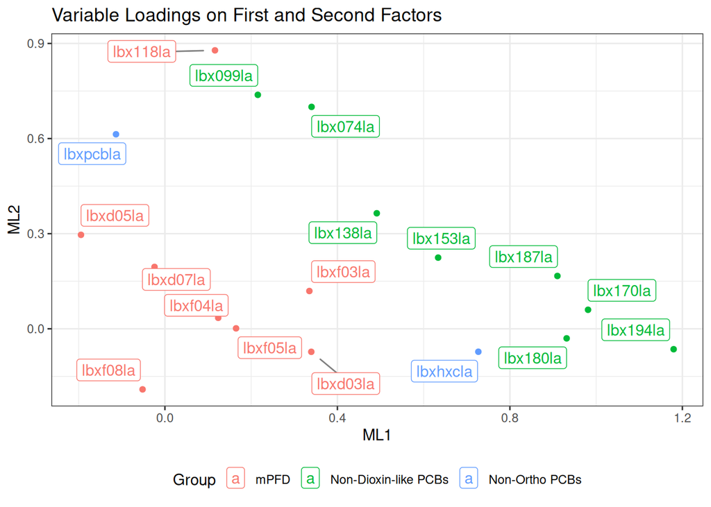

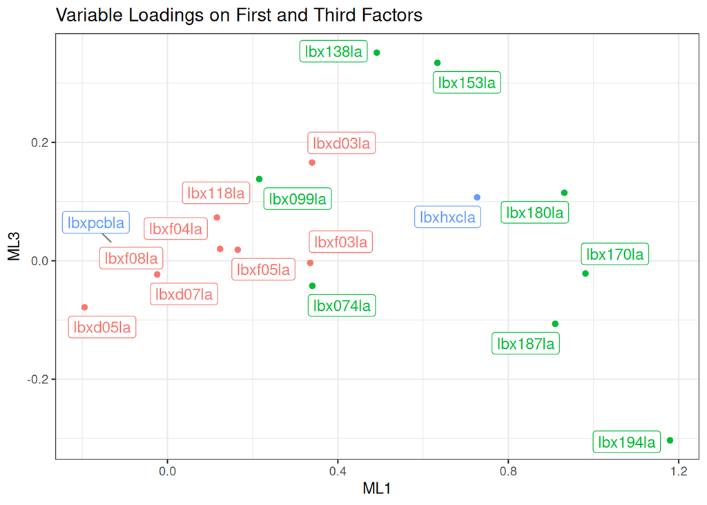

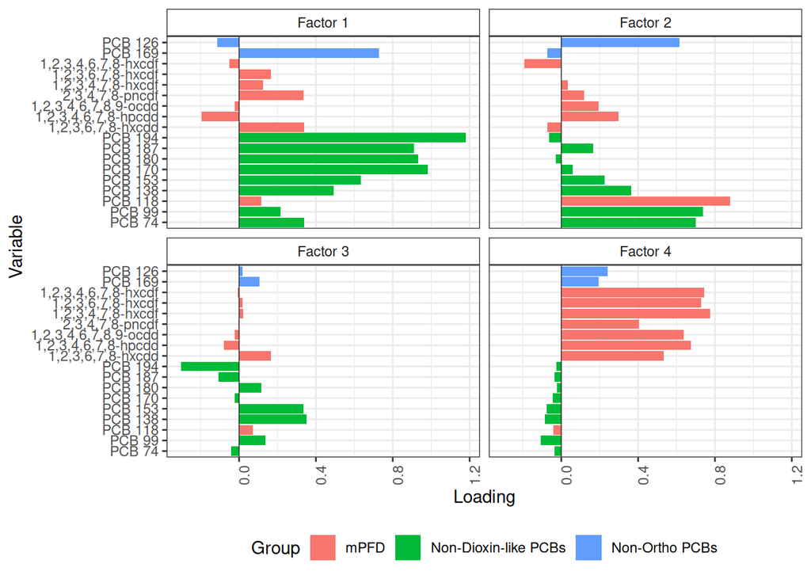

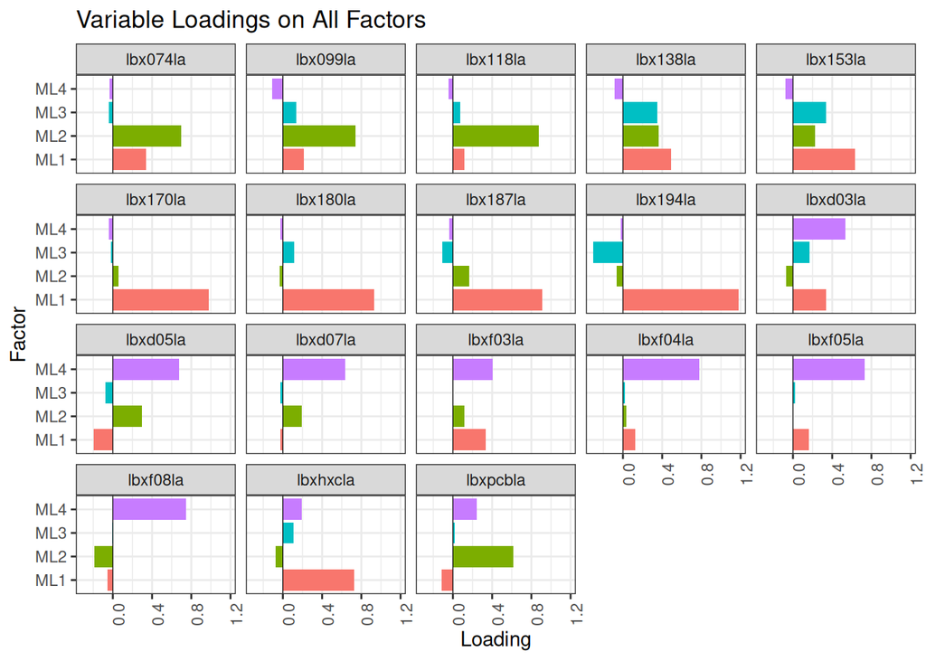

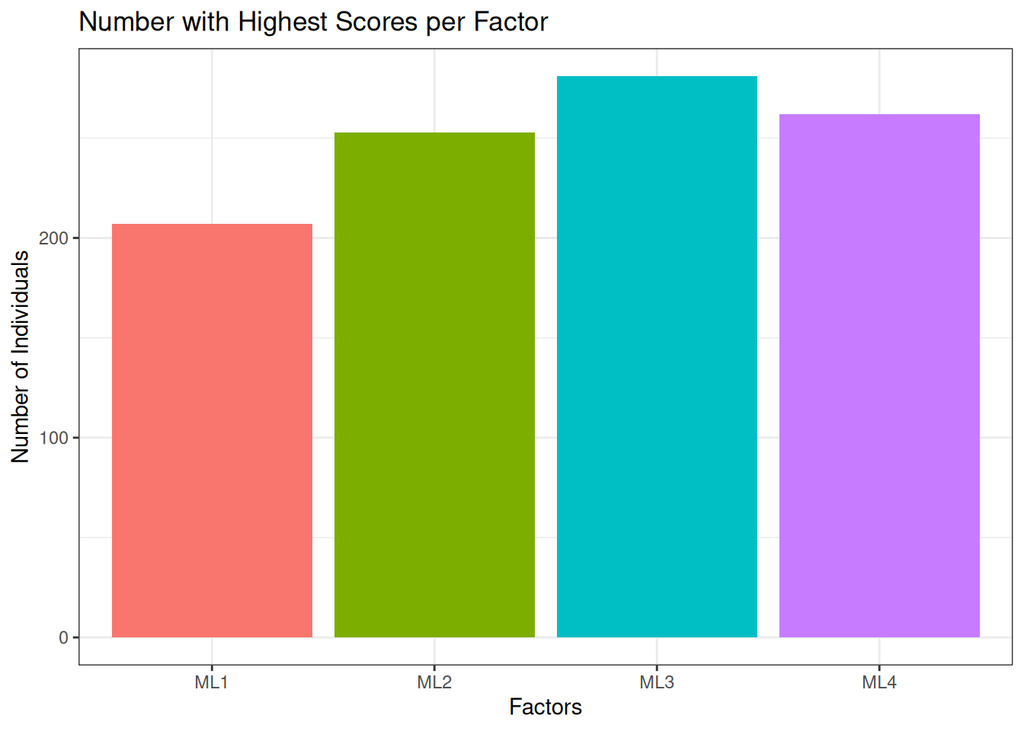

```
## # A tibble: 4 × 2
##   Max   `n()`
##   <chr> <int>
## 1 ML1     207
## 2 ML2     253
## 3 ML3     281
## 4 ML4     262
```

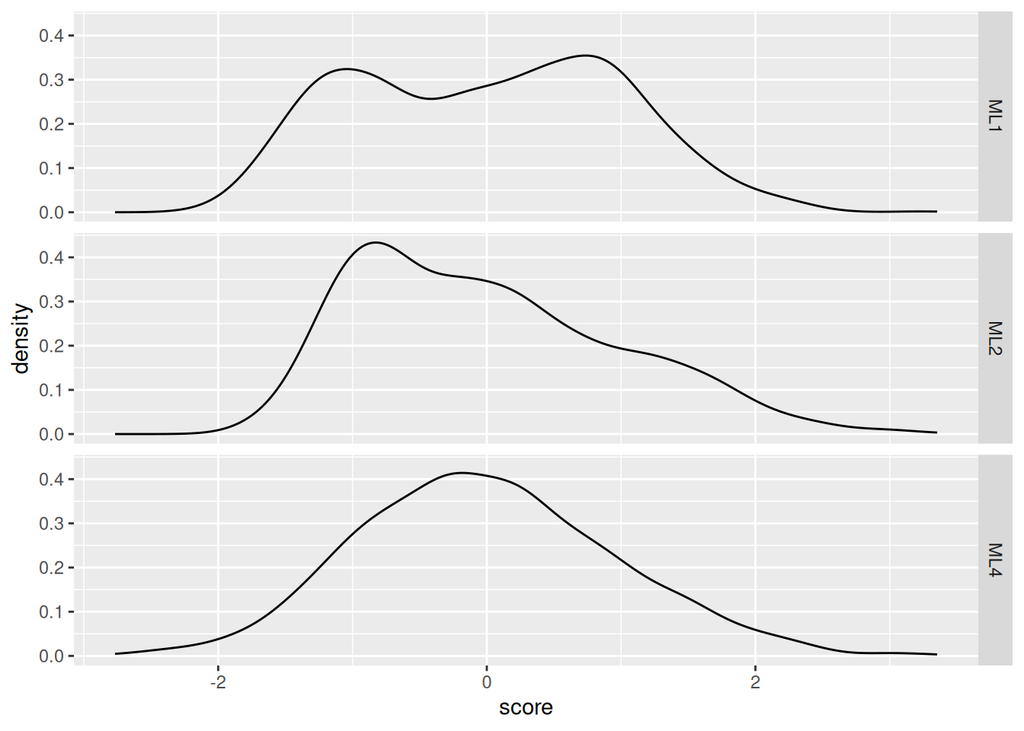

## Health Models

Combine Factor scores with original data outcome and covariates.

### Continuous

```
##
## Call:
## lm(formula = logtelomean ~ ML1 + ML2 + ML3 + ML4 + age_cent +
##     age_sq + lbxwbcsi + lbxlypct + lbxmopct + lbxnepct + lbxeopct +
##     lbxbapct + as.factor(bmi_cat3) + as.factor(edu_cat) + as.factor(race_cat) +
##     male, data = pop_fa)
##
## Residuals:
##      Min       1Q   Median       3Q      Max
## -0.55634 -0.13679 -0.00725  0.12991  0.71209
##
## Coefficients:
##                         Estimate  Std. Error t value            Pr(>|t|)
## (Intercept)           3.39597369  8.12315636   0.418              0.6760
## ML1                   0.00128471  0.01472176   0.087              0.9305
## ML2                   0.02312088  0.01170468   1.975              0.0485 *
## ML3                   0.00682563  0.00949592   0.719              0.4724
## ML4                   0.01128795  0.00942496   1.198              0.2313
## age_cent             -0.00684329  0.00073325  -9.333 <0.0000000000000002 ***
## age_sq               -0.00001331  0.00002295  -0.580              0.5621
## lbxwbcsi             -0.00470912  0.00355970  -1.323              0.1862
## lbxlypct             -0.03261624  0.08120725  -0.402              0.6880
## lbxmopct             -0.03797333  0.08123656  -0.467              0.6403
## lbxnepct             -0.03204554  0.08118837  -0.395              0.6931
## lbxeopct             -0.03158880  0.08123513  -0.389              0.6975
## lbxbapct             -0.01447363  0.08238021  -0.176              0.8606
## as.factor(bmi_cat3)2 -0.01069345  0.01647071  -0.649              0.5163
## as.factor(bmi_cat3)3 -0.02581742  0.01839817  -1.403              0.1609
## as.factor(edu_cat)2   0.01910464  0.01840426   1.038              0.2995
## as.factor(edu_cat)3   0.03161392  0.01772788   1.783              0.0748 .
## as.factor(edu_cat)4   0.00833597  0.02071899   0.402              0.6875
## as.factor(race_cat)2 -0.03504659  0.02731015  -1.283              0.1997
## as.factor(race_cat)3 -0.00340300  0.02854725  -0.119              0.9051
## as.factor(race_cat)4 -0.04001420  0.02511731  -1.593              0.1115
## male                 -0.02636059  0.01484262  -1.776              0.0760 .
## ---
## Signif. codes:  0 '***' 0.001 '**' 0.01 '*' 0.05 '.' 0.1 ' ' 1
##
## Residual standard error: 0.2016 on 981 degrees of freedom
## Multiple R-squared:   0.26,  Adjusted R-squared:  0.2442
## F-statistic: 16.41 on 21 and 981 DF,  p-value: < 0.00000000000000022
```

```
##                                2.5 %         97.5 %
## (Intercept)          -12.54478762648 19.33673499994
## ML1                   -0.02760505072  0.03017447503
## ML2                    0.00015179618  0.04608996808
## ML3                   -0.01180902767  0.02546029423
## ML4                   -0.00720745514  0.02978335271
## age_cent              -0.00828220194 -0.00540437103
## age_sq                -0.00005835284  0.00003172947
## lbxwbcsi              -0.01169461420  0.00227638200
## lbxlypct              -0.19197614866  0.12674365885
## lbxmopct              -0.19739074186  0.12144408310
## lbxnepct              -0.19136837873  0.12727730735
## lbxeopct              -0.19100340650  0.12782581299
## lbxbapct              -0.17613532662  0.14718807059
## as.factor(bmi_cat3)2  -0.04301532977  0.02162842270
## as.factor(bmi_cat3)3  -0.06192171361  0.01028686908
## as.factor(edu_cat)2   -0.01701159698  0.05522088138
## as.factor(edu_cat)3   -0.00317501918  0.06640285282
## as.factor(edu_cat)4   -0.03232266133  0.04899460780
## as.factor(race_cat)2  -0.08863961934  0.01854643399
## as.factor(race_cat)3  -0.05942369776  0.05261770172
## as.factor(race_cat)4  -0.08930403994  0.00927563711
## male                  -0.05548751869  0.00276634861
```

```
## # A tibble: 22 × 5
##    term        estimate std.error statistic p.value
##    <chr>          <dbl>     <dbl>     <dbl>   <dbl>
##  1 (Intercept)   3.40      8.12      0.418   0.676
##  2 ML1           0.0013    0.0147    0.0873  0.930
##  3 ML2           0.0231    0.0117    1.98    0.0485
##  4 ML3           0.0068    0.0095    0.719   0.472
##  5 ML4           0.0113    0.0094    1.20    0.231
##  6 age_cent     -0.0068    0.0007   -9.33    0
##  7 age_sq        0         0        -0.58    0.562
##  8 lbxwbcsi     -0.0047    0.0036   -1.32    0.186
##  9 lbxlypct     -0.0326    0.0812   -0.402   0.688
## 10 lbxmopct     -0.038     0.0812   -0.467   0.640
## # ℹ 12 more rows
```

```
## # A tibble: 1 × 12
##   r.squared adj.r.squared sigma statistic p.value    df logLik   AIC   BIC
##       <dbl>         <dbl> <dbl>     <dbl>   <dbl> <dbl>  <dbl> <dbl> <dbl>
## 1     0.260         0.244 0.202      16.4       0    21   194. -342. -229.
## # ℹ 3 more variables: deviance <dbl>, df.residual <int>, nobs <int>
```

[output not shown]

### Categorical

```
##
## Call:
## lm(formula = logtelomean ~ as.factor(Max) + age_cent + age_sq +
##     lbxwbcsi + lbxlypct + lbxmopct + lbxnepct + lbxeopct + lbxbapct +
##     as.factor(bmi_cat3) + as.factor(edu_cat) + as.factor(race_cat) +
##     male, data = pop_fa)
##
## Residuals:
##      Min       1Q   Median       3Q      Max
## -0.55951 -0.13459 -0.00798  0.12558  0.73297
##
## Coefficients:
##                         Estimate  Std. Error t value            Pr(>|t|)
## (Intercept)           3.32926092  8.21615256   0.405              0.6854
## as.factor(Max)ML2     0.01498714  0.02150480   0.697              0.4860
## as.factor(Max)ML3     0.01817075  0.02067048   0.879              0.3796
## as.factor(Max)ML4     0.01183434  0.02061460   0.574              0.5660
## age_cent             -0.00545808  0.00052563 -10.384 <0.0000000000000002 ***
## age_sq               -0.00001366  0.00002156  -0.634              0.5264
## lbxwbcsi             -0.00574241  0.00357739  -1.605              0.1088
## lbxlypct             -0.03217637  0.08213828  -0.392              0.6953
## lbxmopct             -0.03673720  0.08213899  -0.447              0.6548
## lbxnepct             -0.03158683  0.08211921  -0.385              0.7006
## lbxeopct             -0.03128572  0.08216816  -0.381              0.7035
## lbxbapct             -0.01194947  0.08332476  -0.143              0.8860
## as.factor(bmi_cat3)2 -0.01052147  0.01626408  -0.647              0.5178
## as.factor(bmi_cat3)3 -0.02205009  0.01766470  -1.248              0.2122
## as.factor(edu_cat)2   0.02177669  0.01852383   1.176              0.2400
## as.factor(edu_cat)3   0.03542520  0.01782391   1.988              0.0471 *
## as.factor(edu_cat)4   0.01038153  0.02085182   0.498              0.6187
## as.factor(race_cat)2 -0.04213917  0.02712900  -1.553              0.1207
## as.factor(race_cat)3  0.01218404  0.02822817   0.432              0.6661
## as.factor(race_cat)4 -0.03684400  0.02523106  -1.460              0.1445
## male                 -0.03426568  0.01403444  -2.442              0.0148 *
## ---
## Signif. codes:  0 '***' 0.001 '**' 0.01 '*' 0.05 '.' 0.1 ' ' 1
##
## Residual standard error: 0.203 on 982 degrees of freedom
## Multiple R-squared:  0.2491, Adjusted R-squared:  0.2338
## F-statistic: 16.29 on 20 and 982 DF,  p-value: < 0.00000000000000022
```

```
##                                2.5 %         97.5 %
## (Intercept)          -12.79397446852 19.45249630840
## as.factor(Max)ML2     -0.02721350479  0.05718777821
## as.factor(Max)ML3     -0.02239263592  0.05873413589
## as.factor(Max)ML4     -0.02861938784  0.05228806448
## age_cent              -0.00648957340 -0.00442658519
## age_sq                -0.00005597117  0.00002864739
## lbxwbcsi              -0.01276263067  0.00127780328
## lbxlypct              -0.19336310893  0.12901037809
## lbxmopct              -0.19792532476  0.12445092764
## lbxnepct              -0.19273615836  0.12956248857
## lbxeopct              -0.19253108585  0.12995964145
## lbxbapct              -0.17546452992  0.15156559656
## as.factor(bmi_cat3)2  -0.04243782346  0.02139487614
## as.factor(bmi_cat3)3  -0.05671498996  0.01261481280
## as.factor(edu_cat)2   -0.01457414746  0.05812753407
## as.factor(edu_cat)3    0.00044786717  0.07040252309
## as.factor(edu_cat)4   -0.03053771894  0.05130077858
## as.factor(race_cat)2  -0.09537665547  0.01109830654
## as.factor(race_cat)3  -0.04321043973  0.06757852142
## as.factor(race_cat)4  -0.08635698198  0.01266899188
## male                  -0.06180662324 -0.00672474601
```

```
## # A tibble: 21 × 5
##    term              estimate std.error statistic p.value
##    <chr>                <dbl>     <dbl>     <dbl>   <dbl>
##  1 (Intercept)         3.33      8.22       0.405   0.685
##  2 as.factor(Max)ML2   0.015     0.0215     0.697   0.486
##  3 as.factor(Max)ML3   0.0182    0.0207     0.879   0.380
##  4 as.factor(Max)ML4   0.0118    0.0206     0.574   0.566
##  5 age_cent           -0.0055    0.0005   -10.4     0
##  6 age_sq              0         0         -0.634   0.526
##  7 lbxwbcsi           -0.0057    0.0036    -1.61    0.109
##  8 lbxlypct           -0.0322    0.0821    -0.392   0.695
##  9 lbxmopct           -0.0367    0.0821    -0.447   0.655
## 10 lbxnepct           -0.0316    0.0821    -0.385   0.701
## # ℹ 11 more rows
```

```
## # A tibble: 1 × 12
##   r.squared adj.r.squared sigma statistic p.value    df logLik   AIC   BIC
##       <dbl>         <dbl> <dbl>     <dbl>   <dbl> <dbl>  <dbl> <dbl> <dbl>
## 1     0.249         0.234 0.203      16.3       0    20   187. -329. -221.
## # ℹ 3 more variables: deviance <dbl>, df.residual <int>, nobs <int>
```

## Plot Models

### Continuous

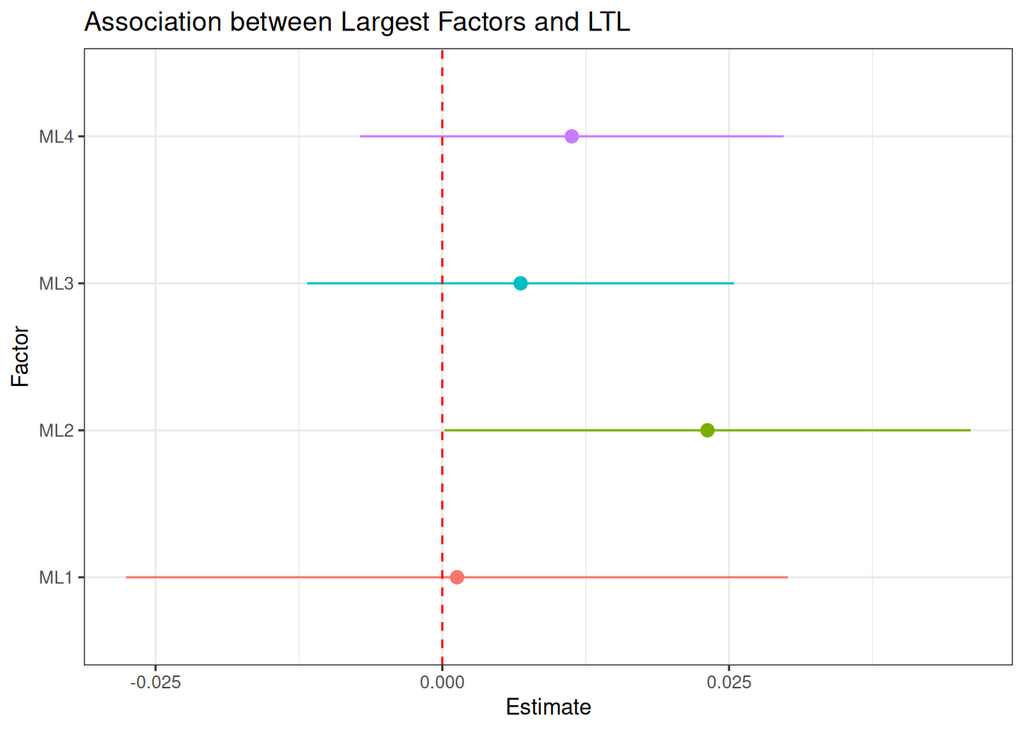

### Categorical

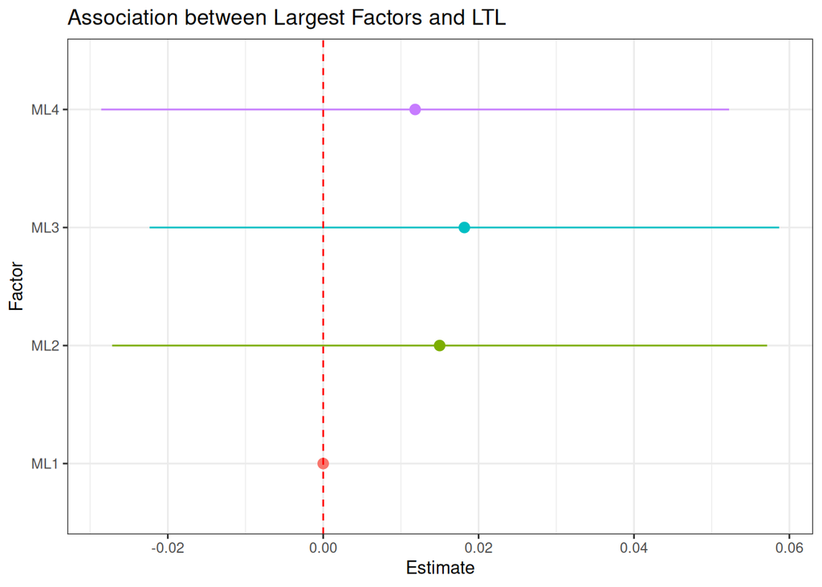